# SCR sin marcas reconocibles (unSCR)

José Jiménez (CSIC-IREC) email: jose.jimenez@csic.es

04/8/2022

## Introducción

El último método que vamos a ver es la captura-recaptura espacial sin marcas reconocibles (*unmarked-SCR* o unSCR), que también se denomina conteos espaciales (*Spatial Counts*). Los modelos de conteos espaciales son otra extensión de los SCR, para el caso de que ninún animal está marcado y por tanto ninguno va a ser reconocible en los dispositivos de captura. Fue desarrollada por Chandler y Royle (2013). Conceptualmente, unSCR es idéntico a SCR, sólo que aquí en vez de trabajar con matrices de observación de individuos por trampa y ocasión de muestreo $Y_{i,j,k}$, trabajaremos con matrices con conteos de individuos sin identificación en cada dispositivo por ocasión de muestreo $Y_{j,k}$, o sea, perdemos la primera dimensión de la matriz (*i*) que corresponde a los individuos. Podemos conceptualizar que en estas matrices la información de los individuos está “contenida” dentro de manera latente, y el objetivo del modelo es extraer esa información latente.

La información de sigma ($\sigma$) que -como recordareis- es el parámetro de escala de la distribución seminormal y es informativo del movimiento de los animales, procede de la información suministrada por la correlación espacial entre capturas. Considerad que esta correlación tiene un valor informativo muy limitado, y esa limitación exige suministrar datos adicionales de telemetría, priors informativos, o bien la identificación de algún individuo. Si no se usa con otra información adicional, unSCR es un método de muy baja precisión.

Una cuestión importante a tener en cuenta es que unSCR sólo funciona razonablemente bien para bajas densidades, y cuando hay bajo solapamiento de las áreas de campeo. En estas circunstancias este método puede discriminar adjudicando las identidades según la ubicación espacial de las observaciones de los individuos, considerando simultáneamente el valor de $\sigma$.

En este caso vamos a emplear un muestreador específico, creado por Augustine (2022) que agiliza la ejecución del modelo al muestrear sólo cuando $z=1$. Este muestreador se puede usar en otros modelos SCR. Al igual que para SCR, vamos a ejecutar los modelos usando R (R Core Team, 2022) y Nimble (De Valpine et al., 2017).

Recomiendo repetir los análisis que se ejecutan aquí, cambiando los valores de $set.seed()$ que controlan la aleatoriedad de las simulaciones. Para ampliar conocimientos resulta adecuado leer las referencias de este documento y el libro Spatial Capture-Recapture de Royle et al. (2017) https://www.sciencedirect.com/book/9780124059399/spatial- capture-recapture.

## Simulación de datos

Vamos a simular datos en $R$ y a ejecutar el modelo unSCR. En este caso vamos a simular 20 individuos (que será la población a estimar). Como os he comentado antes, sin información adicional, esta modelo es muy poco preciso. Para solventarlo, voy a utilizar aquí un prior informativo con una distribución gamma.

Para generar los datos simulados vamos a simular los datos directamente, sin usar una función predefinida.

```r
setwd('C:/Users/Usuario/OneDrive - Universidad de Castilla-La Mancha/00 CURSOS/28 Curso Mexico')
source("SCR_functions.R")
library(scrbook)
library(lattice)
library(coda)
library(mcmcOutput)
library(nimble)
nimble:::setNimbleOption('useSafeDeparse', FALSE)
nimbleOptions('useSafeDeparse')
```

```
## [1] FALSE
```

```r
source("sSampler.R")
```

Datos a simular. Aquí podeis cambiar vosotros los valores de *N* y de *K*. Os daréis cuenta que al incrementar $N$ vamos a ir perdiendo precisión.

```r
N <- 20  # Tamaño de población
K <- 15  # Ocasiones de muestreo
```

Vamos a generar nuestros datos. Los veremos gráficamente y exploraremos con *str*:

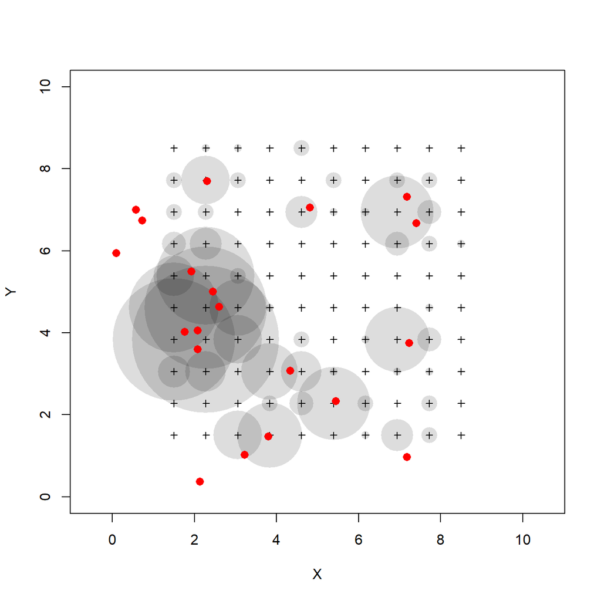

```r
set.seed(2224)

tr<-seq(1.5,8.5, length=10)
X<-cbind(rep(tr,each=length(tr)),rep(tr,times=length(tr))) # 100 coord. trampas

# Creación de la red de trampas
plot(X, xlim=c(0,10), ylim=c(0,10), pch=3, cex=0.75, xlab="X", ylab="Y", asp=TRUE)
xlim <- c(0,10); ylim <- c(0,10)

# Generación de los centros de actividad
S <- cbind(runif(N, xlim[1], xlim[2]), runif(N, ylim[1], ylim[2]))
points(S, pch=16, col=2)

sigma <- 0.5
lambda0 <- 0.4
J <- nrow(X)

yy <- array(NA, c(N, J, K))
for(j in 1:J) {
  dist <- sqrt((X[j,1]-S[,1])^2 + (X[j,2]-S[,2])^2)
  lambda <- lambda0*exp(-dist^2/(2*sigma^2))
  for(k in 1:K) {
    yy[,j,k] <- rpois(N, lambda)
  }
}

n <- apply(yy, c(2,3), sum) # sólo hay información j,k

# Lo anadimos al ploteado:
tot<-apply(n, 1,sum)
symbols(X, circles=tot/10, inches=F,bg="#00000022", fg=NULL, add=T)
points(X, pch=3, cex=0.75); points(S, pch=16, col=2)
points(S, pch=16, col="red", cex=1.25)
```

```r
# El total de datos a usar es:
sum(n)
```

```
## [1] 225
```

Exploramos los datos, y en este caso de estudio vamos a sumar la información a lo largo de $K$, asumiendo que no hay variación temporal en nuestros datos.

```r
n1<-apply(n, 1, sum)
```

Aumentado de datos

```r
M <- 150
```

Como comentaba al principio, unSCR sin informacion adicional va a ser muy poco preciso. Vamos a usar un prior informativo para sigma, generandolo con una distribucion gamma. Si queremos usar un sigma de $moda=0.5$ y $SD=0.1$:

```r
mode <- 0.5
sd <- 0.1

# Obtenemos los parámetros de ratio y forma:
ra = ( mode + sqrt( mode^2 + 4*sd^2 ) ) / ( 2 * sd^2 )
sh = 1 + mode * ra

show(sh)
```

```
## [1] 26.96291
```

```r
show(ra)
```

```
## [1] 51.92582
```

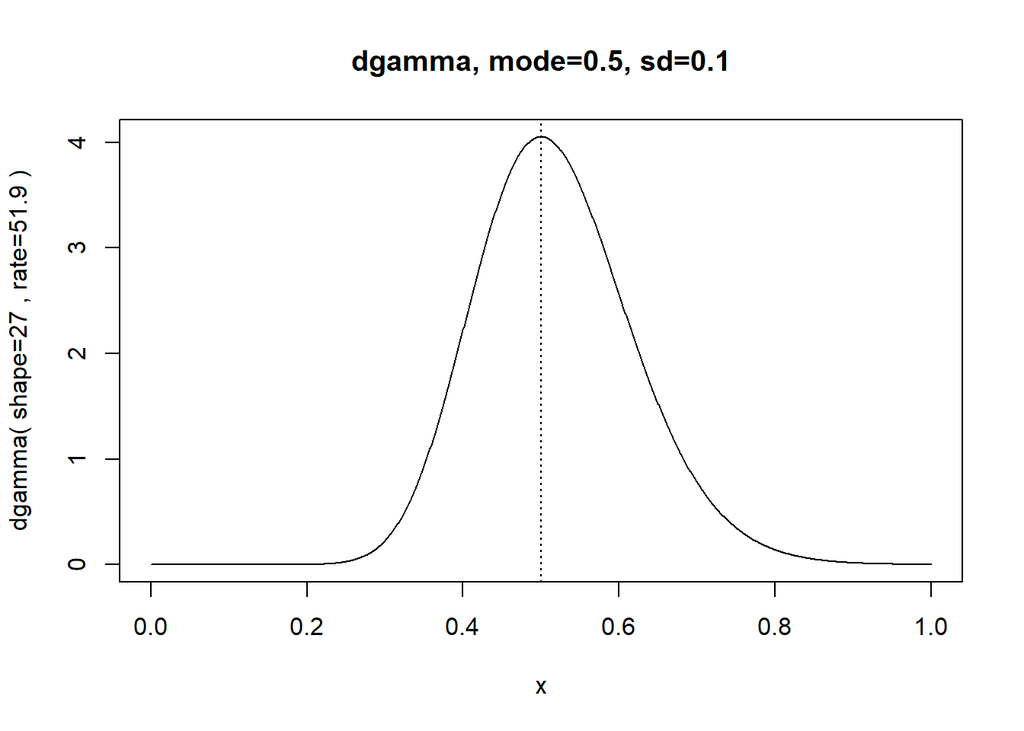

```r
# Ploteamos nuestra información a priori:
x = seq(0,mode+5*sd,len=1001)
plot( x , dgamma( x , shape=sh , rate=ra ) , type="l" ,
      main=paste("dgamma, mode=",mode,", sd=",sd,sep="") ,
      ylab=paste("dgamma( shape=",signif(sh,3)," , rate=",signif(ra,3)," )",
                 sep="") )
abline( v=mode , lty="dotted" )
```

## Código SCR

```r
## definimos el modelo
code <- nimbleCode({

  # Priors
  sigma ~ dgamma(sh,ra) # sigma
  sigma2<-2*sigma^2
  lam0 ~ dunif(0,5)     # ratio base de detección
  psi ~ dunif(0,1)      # aumentado de datos

  for(i in 1:M) {
    z[i] ~ dbern(psi)
    s[i,1] ~ dunif(xlim[1], xlim[2])
    s[i,2] ~ dunif(ylim[1], ylim[2])
    dist2[i,1:J] <- (s[i,1] - X[1:J,1])^2 + (s[i,2] - X[1:J,2])^2
    lam[i,1:J] <- lam0*exp(-dist2[i,1:J]/sigma2)*z[i]*K
  }

  for(j in 1:J){
    bigLambda[j] <- sum(lam[1:M,j])
    n[j] ~ dpois(bigLambda[j])
  }

  N <- sum(z[1:M])

})
```

Cargamos el muestreador de Augustine (2022)

```r
source("sSampler.R")
```

## Preparamos constantes, datos e inicios

Preparamos las constantes:

```r
str(constants <- list(M=M,        # Aumentado de datos
                      K=K,        # ocasiones de muestreo
                      J=J,        # número de trampas
                      sh=sh,      # parámetros de la distribución gamma
                      ra=ra))     # id
```

```
## List of 5
##  $ M : num 150
##  $ K : num 15
##  $ J : int 100
##  $ sh: num 27
##  $ ra: num 51.9
```

… los datos…

```r
str(data    <-   list(n=n1,       # conteos sumados sobre K
                      X=X,        # coordenadas de las cámaras trampa
                      xlim=xlim,  # extremos (X) del espacio de estados
                      ylim=ylim)) # extremos (Y) del espacio de estados
```

```
## List of 4
##  $ n   : int [1:100] 0 0 4 15 11 5 3 2 2 0 ...
##  $ X   : num [1:100, 1:2] 1.5 1.5 1.5 1.5 1.5 1.5 1.5 1.5 1.5 1.5 ...
##  $ xlim: num [1:2] 0 10
##  $ ylim: num [1:2] 0 10
```

```r
# Inicios para las ubicaciones latentes
s.start<-cbind(runif(M, xlim[1], xlim[2]), runif(M, ylim[1], ylim[2]))
z<-rep(1,M)
str(inits   <-   list(lam0=runif(1,0,1),
                      sigma=runif(1,0,1),
                      psi=runif(1,0,1),
                      s=s.start,
                      z=z))
```

```
## List of 5
##  $ lam0 : num 0.344
##  $ sigma: num 0.801
##  $ psi  : num 0.885
##  $ s    : num [1:150, 1:2] 5.0889 0.0295 6.5303 2.2352 5.5067 ...
##  $ z    : num [1:150] 1 1 1 1 1 1 1 1 1 1 ...
```

Parámetros que vamos a monitorizar

```r
# No tiene sentido aquí monitorizar sigma, ya que va a estar influida por
# el prior generado por la distribución gamma
params <- c('N', 'lam0', 'psi')
```

## Compilamos y ejecutamos:

```r
Rmodel <- nimbleModel(code=code, constants=constants, data=data, inits=inits)
```

```
## Defining model
```

```
## Building model
```

```
## Setting data and initial values
```

```
## Running calculate on model
##   [Note] Any error reports that follow may simply reflect missing values in model variables.
```

```
## Checking model sizes and dimensions
```

```r
Rmodel$initializeInfo()
```

```
##   [Note] All model variables are initialized.
```

```r
Rmodel$calculate()
```

```
## [1] -3313.906
```

```r
Cmodel <- compileNimble(Rmodel)
```

```
## Compiling
##   [Note] This may take a minute.
##   [Note] Use 'showCompilerOutput = TRUE' to see C++ compilation details.
```

```r
conf<-configureMCMC(Rmodel, monitors=c('N','lam0','psi','s','z'), thin=1)
```

```
## ===== Monitors =====
## thin = 1: lam0, N, psi, s, z
## ===== Samplers =====
## RW sampler (303)
##   - sigma
##   - lam0
##   - psi
##   - s[]  (300 elements)
## binary sampler (150)
##   - z[]  (150 elements)
```

```r
conf$removeSampler(paste("s[1:",M,", 1:2]", sep=""))
for(i in 1:M){
  conf$addSampler(target = paste("s[",i,", 1:2]", sep=""),
                  type = 'sSampler',
                  control=list(i=i,
                               xlim=Rmodel$xlim,
                               ylim=Rmodel$ylim,
                               scale=0.25),
                  silent = TRUE)
}

MCMC <- buildMCMC(conf)

Comp_MCMC <- compileNimble(MCMC, project = Rmodel)
```

```
## Compiling
##   [Note] This may take a minute.
##   [Note] Use 'showCompilerOutput = TRUE' to see C++ compilation details.
```

```r
# Ejecutamos el modelo
nb=1000      # Iteraciones a desechar
ni=5000 +nb  # Iteraciones
nc=3         # Cadenas


start.time2<-Sys.time()
outNim <- runMCMC(Comp_MCMC, niter = ni , nburnin = nb , nchains = nc, inits=inits,
                  setSeed = TRUE, progressBar = TRUE, samplesAsCodaMCMC = TRUE)
```

```
## Running chain 1 ...
```

```
## |-------------|-------------|-------------|-------------|
## |-------------------------------------------------------|
```

```
## Running chain 2 ...
```

```
## |-------------|-------------|-------------|-------------|
## |-------------------------------------------------------|
```

```
## Running chain 3 ...
```

```
## |-------------|-------------|-------------|-------------|
## |-------------------------------------------------------|
```

```r
end.time<-Sys.time()
end.time-start.time2 # tiempo de ejecucion
```

```
## Time difference of 9.432851 mins
```

## Resultados

Compararemos lo simulado con los valores posteriores, y así podemos tener una idea de que tal funciona nuestro modelo ¡Pero atención, y no nos deslumbremos demasiado con él! Aquí estamos en una simulación. En realidad, cualquier forma de heterogeneidad puede afectar seriamente los resultados. Es un modelo que precisa: 1) muchos datos; 2) baja densidad y 3) estricto cumplimiento de las premisas de estos modelos.

```r
summary(outNim[,c('N','lam0','psi')])
```

```
##
## Iterations = 1:5000
## Thinning interval = 1
## Number of chains = 3
## Sample size per chain = 5000
##
## 1. Empirical mean and standard deviation for each variable,
##    plus standard error of the mean:
##
##         Mean      SD  Naive SE Time-series SE
## N    22.9531 4.34713 0.0354942        0.15342
## lam0  0.4609 0.06409 0.0005233        0.00261
## psi   0.1573 0.04103 0.0003350        0.00117
##
## 2. Quantiles for each variable:
##
##          2.5%     25%     50%     75%   97.5%
## N    16.00000 20.0000 22.0000 25.0000 33.0000
## lam0  0.34664  0.4172  0.4568  0.5025  0.5967
## psi   0.08863  0.1279  0.1541  0.1825  0.2479
```

## Chequeamos convergencia de las cadenas de Markov

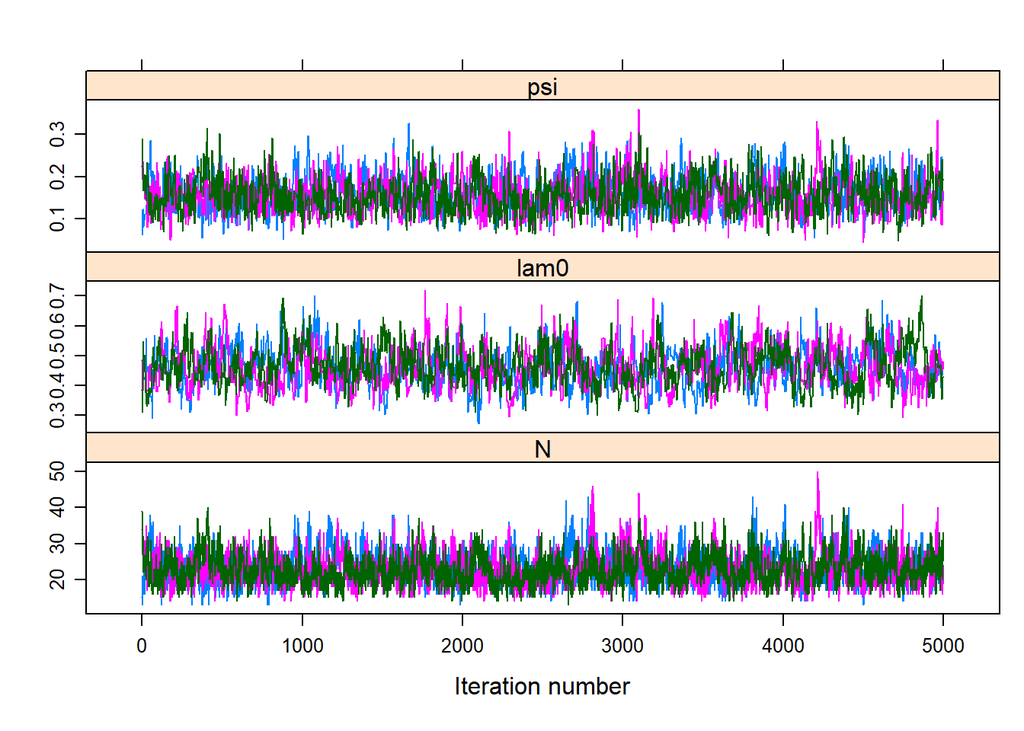

```r
#diagPlot(outNim)
xyplot(outNim[,c('N','lam0','psi')])
```

## Distribución espacial de los centros de actividad

```r
mco <- mcmcOutput(outNim)
s1<-mco$s[,,1] ; Sx<-as.matrix(s1)
s2<-mco$s[,,2] ; Sy<-as.matrix(s2)
z<-mco$z       ; z<- as.matrix(z)

delta<-1.5
Xl<-min(X[,1])-delta
Xu<-max(X[,1])+delta
Yl<-min(X[,2])-delta
Yu<-max(X[,2])+delta
obj<-list(Sx=Sx,Sy=Sy,z=z)

par(mfrow=c(1,1))
Spat<-SCRdensity(obj, nx=100, ny=100, Xl=Xl, Xu=Xu, Yl=Yl, Yu=Yu)
```

```
## mean:  0.2295313
```

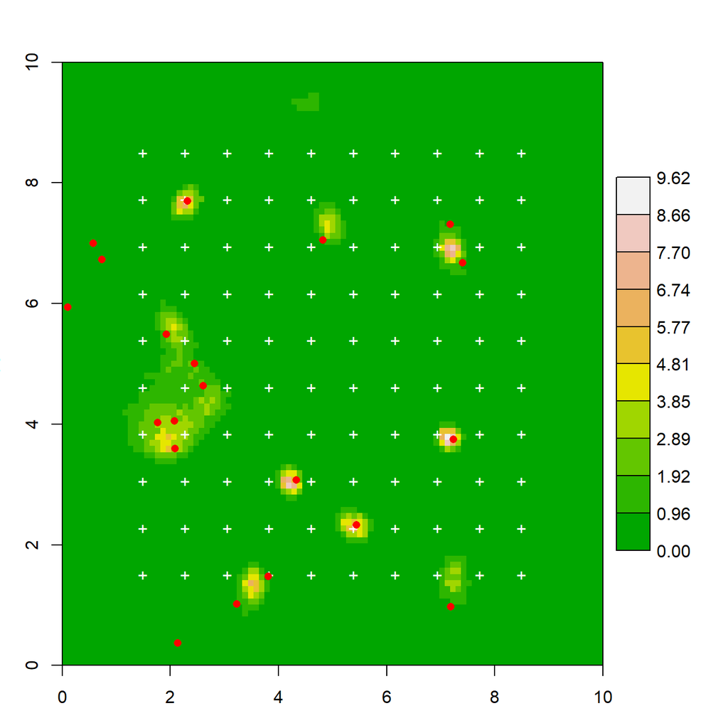

```r
points(X, pch="+", col="white")
points(S, col="red", pch=16)
```

## Referencias

Augustine, B. (2022). UnmarkedSCR. sSampler. Retrieved from https://github.com/benaug/UnmarkedSCR/blob/main/sSampler.R/.

Chandler, R. B., Royle, J. A. (2013). Spatially-explicit models for inference about density in unmarked populations. *The Annals of Applied Statistics, 7*(2), 936–954. doi:10.1214/12-AOAS610

De Valpine, P., Turek, D., Paciorek, C. J., Anderson-Bergman, D., Lang, T., & Bodik, R. (2017). Programming with models: writing statistical algorithms for general model structures with NIMBLE. *Journal of Computational and Graphical Statistics*, 26, 403–413.DOI:10.1080/10618600.2016.1172487

R Core Team. (2020). R: A language and environment for statistical computing. R Foundation for Statistical Computing. Vienna, Austria. Retrieved from https://www.r-project.org/.

Royle, J. A., Chandler, R. B., Sollmann, R., Gardner, B. (2014). *Spatial capture-recapture*. Waltham, Massachusetts: Elsevier, Academic Press. doi:10.1016/B978-0-12-405939-9.00026-8